# Análisis de lo supuestos

Luis Fernando Apáez Álvarez

13/11/2021

# Normalidad

Linealidad y homocedasticidad

Normalidad

## Ejemplo de verificación de la normalidad

Comenzamos por cargar y ver los datos

```r
library(latex2exp)

Datos = read.csv("ejemplo4.csv")
head(Datos)
```

```
##   x          y
## 1 1  0.9395244
## 2 2  2.7698225
## 3 3  7.0587083
## 4 4  9.0705084
## 5 5 13.6292877
## 6 6 20.7150650
```

donde el conjunto de datos ya había sido trabajado con anterioridad.

## Linealidad y homocedasticidad

Vemos el scatterplot inicial

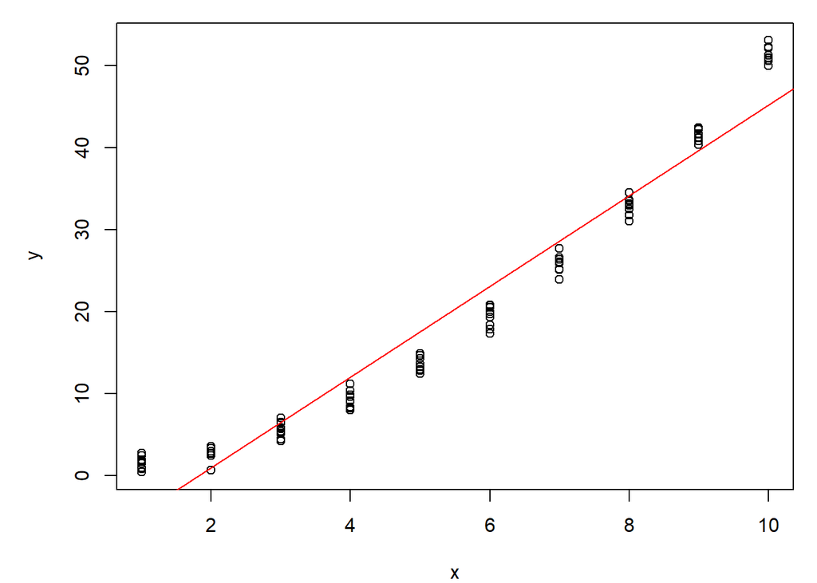

```r
# Realizamos el ajuste del modelo
fit=lm(y~x, data=Datos)

# Scatterplot
par(mfrow=c(1,1))
par(mar=c(4, 5, 1, 1))
plot(Datos$x, Datos$y, xlab = TeX("$x$"), ylab=TeX("$y$"))
abline(fit, col="red")
```

Procedemos a transformar los datos para arreglar los problemas de linealidad y homocedasticidad

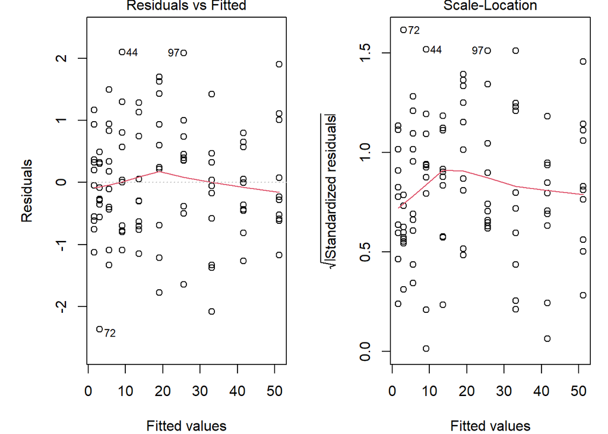

```r
#Se transforma X a X^2 para lograr linealidad
Datos$Xprima=Datos$x^2

# Ajuste del modelo con los datos transformados
fit2=lm(y~Xprima, data=Datos)


#gráficas para linealidad y homocedasticidad
par(mar=c(4, 5, 1, 1))
par(mfrow=c(1,2))
plot(fit2, 1)
plot(fit2, 3)
```

## Normalidad

Como en el ejemplo pasado de normalidad, analizaremos los casos cuando $n$ es grande y cuando es pequeño.

- Consideremos cuando $n$ es grande. Comenzamos por ver la Q-Qplot que `R` trae por defecto

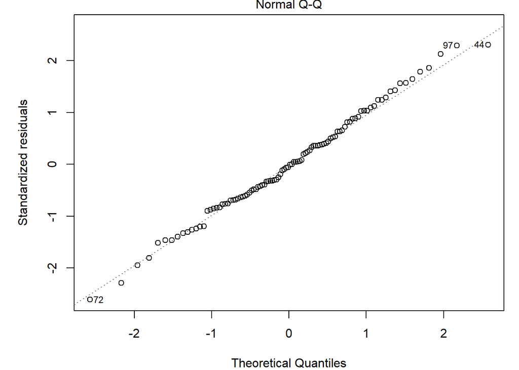

  ```r
  #gráfica QQplot directa de R

  par(mar=c(4, 5, 1, 1))
  par(mfrow=c(1,1))
  plot(fit2, 2)
  ```

  notemos que en este caso no hay evidencia en contra de la normalidad, al menos por la información que nos arroja la Q-Qplot. Procedemos pues al análisis de las pruebas de hipótesis

  ```r
  # Se usan los residuales estandarizados y los cuantiles de una normal

  # R tiene una función para crear errores de forma automatizada
  library(broom)

  # Agregamos los errores calculados al dataframe original
  Datosfit2=augment(fit2)
  ```

  y efectuamos

  ```r
  shapiro.test(Datosfit2$.std.resid)
  ```

  ```
  ##
  ##  Shapiro-Wilk normality test
  ##
  ## data:  Datosfit2$.std.resid
  ## W = 0.99368, p-value = 0.9256
  ```

  donde no se está rechazando $H_{0}$ (que es justamente lo que buscamos). Después, con las restantes dos pruebas

  ```r
  library(nortest)
  library(normtest)

  nortest::lillie.test(Datosfit2$.std.resid)
  ```

  ```
  ##
  ##  Lilliefors (Kolmogorov-Smirnov) normality test
  ##
  ## data:  Datosfit2$.std.resid
  ## D = 0.05564, p-value = 0.6265
  ```

  ```r
  normtest::jb.norm.test(Datosfit2$.std.resid)
  ```

  ```
  ##
  ##  Jarque-Bera test for normality
  ##
  ## data:  Datosfit2$.std.resid
  ## JB = 0.19216, p-value = 0.905
  ```

  Podemos ver lo que pasa con el modelo en el que no transformamos a la $x$:

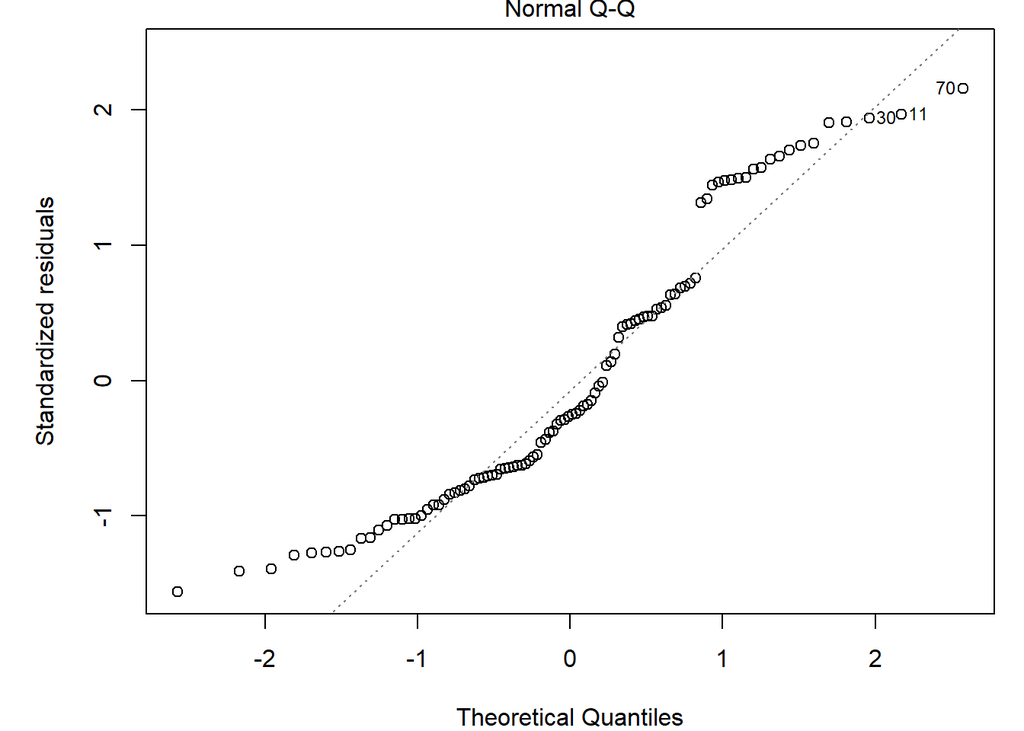

  ```r
  # Q-Qplot
  par(mar=c(4, 5, 1, 1))
  par(mfrow=c(1,1))
  plot(fit, 2)
  ```

  y las pruebas de hipótesis

  ```r
  Datosfit=augment(fit)
  shapiro.test(Datosfit$.std.resid)
  ```

  ```
  ##
  ##  Shapiro-Wilk normality test
  ##
  ## data:  Datosfit$.std.resid
  ## W = 0.92316, p-value = 2.08e-05
  ```

  ```r
  nortest::lillie.test(Datosfit$.std.resid)
  ```

  ```
  ##
  ##  Lilliefors (Kolmogorov-Smirnov) normality test
  ##
  ## data:  Datosfit$.std.resid
  ## D = 0.1273, p-value = 0.0004008
  ```

  ```r
  normtest::jb.norm.test(Datosfit$.std.resid)
  ```

  ```
  ##
  ##  Jarque-Bera test for normality
  ##
  ## data:  Datosfit$.std.resid
  ## JB = 8.3681, p-value = 0.0205
  ```

  en las que se rechaza $H_{0}$, es decir, se rechaza que $e_{st_{1}},\ldots, e_{st_{n}}$ provienen de una normal.

  Con base en lo anterior tenemos evidencia contundente en contra de la normalidad en el modelo no transformado.
- Procedemos a ver el caso en se considera a la $n$ pequeña. Comenzamos por obtener los errores studentizados del ajuste del modelo con los datos transformados

  ```r
  library(MASS)
  ResStudent=studres(fit2)
  ```

  y después vemos la Q-Q plot

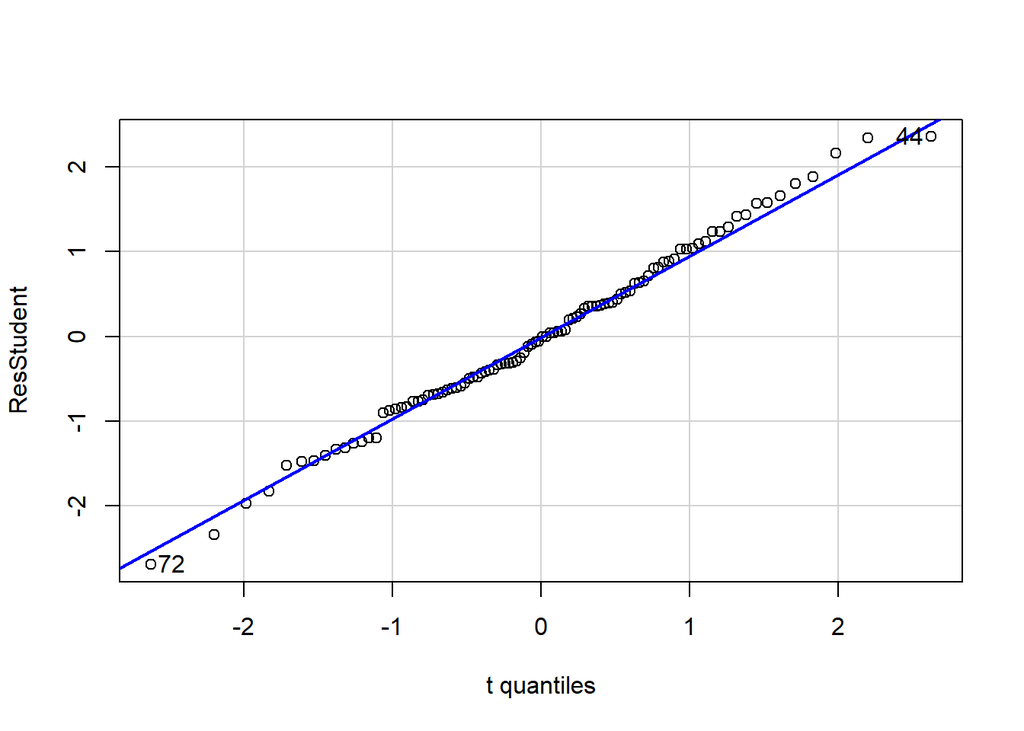

  ```
  ## [1] 72 44
  ```

  ```r
  # Para esta qqplot requerimos de la librería car
  library(car)

  qqPlot(ResStudent, dist="t", df=length(ResStudent)-3,  envelope=FALSE)
  ```

  o laternativamente podemos utilizar

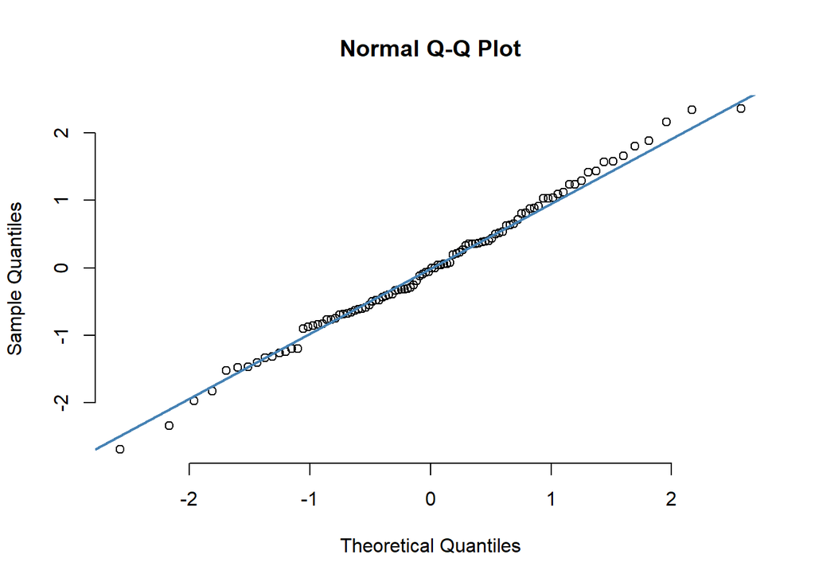

  ```r
  qqnorm(ResStudent, pch = 1, frame = FALSE)
  qqline(ResStudent, col = "steelblue", lwd = 2)
  ```

  siendo las funciones `qqnorm` y `qqline` incluidas como base en `R`. Podemos coparar dichas gráficas

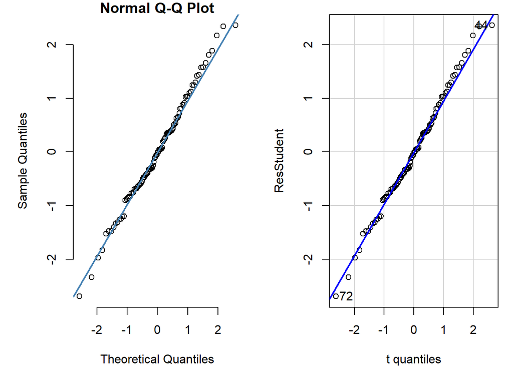

  ```
  ## [1] 72 44
  ```

  ```r
  par(mar=c(4, 5, 1, 1))
  par(mfrow=c(1,2))
  qqnorm(ResStudent, pch = 1, frame = FALSE)
  qqline(ResStudent, col = "steelblue", lwd = 2)
  qqPlot(ResStudent, dist="t", df=length(ResStudent)-3,  envelope=FALSE)
  ```

  Finalmente, la prueba de hipótesis de *Kolmogorov_Smirnov*:

  ```r
  ks.test(ResStudent, "pt", length(ResStudent)-3)
  ```

  ```
  ##
  ##  One-sample Kolmogorov-Smirnov test
  ##
  ## data:  ResStudent
  ## D = 0.055383, p-value = 0.9189
  ## alternative hypothesis: two-sided
  ```

  en el que no se rechaza $H_{0}$. Así, nuevamente no estamos encontrando evidencia en contra de la normalidad en el modelo con los datos transformados. No obstante, ene l modelo con los datos no transformados tenemos que

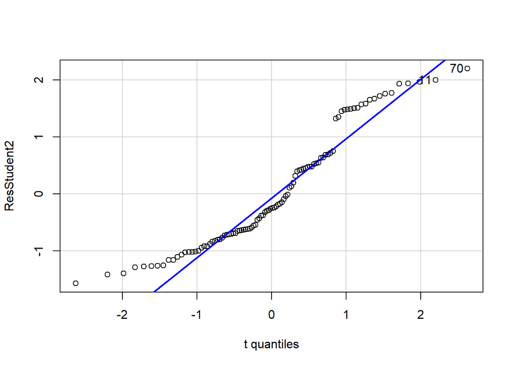

  ```
  ## [1] 70 11
  ```

  ```r
  # Errores studentizados
  ResStudent2=studres(fit)

  # Gráfica que trae por defecto R
  qqPlot(ResStudent2, dist="t", df=length(ResStudent2)-3,  envelope=FALSE)
  ```

  y la prueba de hipótesis

  ```r
  ks.test(ResStudent2, "pt", length(ResStudent)-3)
  ```

  ```
  ##
  ##  One-sample Kolmogorov-Smirnov test
  ##
  ## data:  ResStudent2
  ## D = 0.12593, p-value = 0.08386
  ## alternative hypothesis: two-sided
  ```